# CASE STUDY 2

Part 2: Cleaning the raw data 2a) Read the csv into R and take a look at the data set. Output how many rows and columns the data.frame is.

```r
Data <- read.csv('CaseStudy2-data.csv')

# how many rows and columns the data.frame is?
Dim=dim(Data)
cat('Number of rows are equal to',Dim[1])
```

```
## Number of rows are equal to 1470
```

```r
cat('\nNumber of columns are equal to',Dim[2])
```

```
##
## Number of columns are equal to 35
```

2b)The column names are either too much or not enough. Change the column names so that they do not have spaces, underscores, slashes, and the like. All column names should be under 12 characters. Make sure you’re updating your codebook with information on the tidied data set as well.

```r
# Here, columns have been changed manually becuase there is no unique algorithm to explain them all
names(Data)<-c("Age","Attrition","BusinessTrvl","DailyRate","Department","DistFromHome","Education","EduField","EmployeeCnt","EmployeeNum","EnvSatfction","Gender","HourlyRate","JobInvolmnt","JobLevel","JobRole","JobSatfction","MaritalStat","MonthlyIncm","MonthlyRate","NumCmpWorked","Over18","OverTime","PrcntSalHike","PerfRating","RlnSatfctn","StandardHrs","StockOptLvl","TotWrkngYrs","TrngTmsLstYr","WrkLifeBal","YrsAtCompany","YrsInCrntRl","YrsSncLstPrm","YrsWthCurMgr")

colnames(Data)
```

```
##  [1] "Age"          "Attrition"    "BusinessTrvl" "DailyRate"
##  [5] "Department"   "DistFromHome" "Education"    "EduField"
##  [9] "EmployeeCnt"  "EmployeeNum"  "EnvSatfction" "Gender"
## [13] "HourlyRate"   "JobInvolmnt"  "JobLevel"     "JobRole"
## [17] "JobSatfction" "MaritalStat"  "MonthlyIncm"  "MonthlyRate"
## [21] "NumCmpWorked" "Over18"       "OverTime"     "PrcntSalHike"
## [25] "PerfRating"   "RlnSatfctn"   "StandardHrs"  "StockOptLvl"
## [29] "TotWrkngYrs"  "TrngTmsLstYr" "WrkLifeBal"   "YrsAtCompany"
## [33] "YrsInCrntRl"  "YrsSncLstPrm" "YrsWthCurMgr"
```

2c)Some columns are, due to Qualtrics, malfunctioning. Here we chose Over18 and TrainingTimesLastYear becuase it seems unrelevent to the performance.

```r
Data <- subset(Data, select = -c(Over18,TrngTmsLstYr))
print(Data)
```

[output not shown]

[output cut: 10282 more lines]

2d)Make sure your columns are the proper data types (i.e., numeric, character, etc.). If they are incorrect, convert them.

```r
# here we have checked all columns and correct them accordingly. Columns are either integer or factor but we have change them all to their correct format.
Data$Age <- as.integer(Data$Age)
Data$Attrition <- as.factor(Data$Attrition)
Data$BusinessTrvl <- as.factor(Data$BusinessTrvl)
Data$DailyRate <- as.integer(Data$DailyRate)
Data$Department <- as.factor(Data$Department)
Data$DistFromHome <- as.integer(Data$DistFromHome)
Data$Education <- as.integer(Data$Education)
Data$EduField <- as.factor(Data$EduField)
Data$EmployeeCnt <- as.integer(Data$EmployeeCnt)
Data$EmployeeNum <- as.integer(Data$EmployeeNum)
Data$EnvSatfction <- as.integer(Data$EnvSatfction)
Data$Gender <- as.factor(Data$Gender)
Data$HourlyRate <- as.integer(Data$HourlyRate)
Data$JobInvolmnt <- as.integer(Data$JobInvolmnt)
Data$JobLevel <- as.integer(Data$JobLevel)
Data$JobRole <- as.factor(Data$JobRole)
Data$JobSatfction <- as.integer(Data$JobSatfction)
Data$MaritalStat <- as.factor(Data$MaritalStat)
Data$MonthlyIncm <- as.integer(Data$MonthlyIncm)
Data$MonthlyRate <- as.integer(Data$MonthlyRate)
Data$NumCmpWorked <- as.integer(Data$NumCmpWorked)
Data$OverTime <- as.factor(Data$OverTime)
Data$PrcntSalHike <- as.integer(Data$PrcntSalHike)
Data$PerfRating <- as.integer(Data$PerfRating)
Data$RlnSatfctn <- as.integer(Data$RlnSatfctn)
Data$StandardHrs <- as.integer(Data$StandardHrs)
Data$StockOptLvl <- as.integer(Data$StockOptLvl)
Data$TotWrkngYrs <- as.integer(Data$TotWrkngYrs)
Data$WrkLifeBal <- as.integer(Data$WrkLifeBal)
Data$YrsAtCompany <- as.integer(Data$YrsAtCompany)
Data$YrsInCrntRl <- as.integer(Data$YrsInCrntRl)
Data$YrsSncLstPrm <- as.integer(Data$YrsSncLstPrm)
Data$YrsWthCurMgr <- as.integer(Data$YrsWthCurMgr)

Data
```

[output not shown]

[output cut: 10282 more lines]

3. Preliminary Analysis 3a) Remove all observations where the participant is under age 18. No further analysis of underage individuals is permitted by your client. Remove any other age outliers as you see fit, but be sure to tell what you’re doing and why?

```r
write.csv(Data, "Datacleaning.csv", sep=" ")
newage <- Data$Age[c(-18)]
```

3b) Please provide (in table format or similar), descriptive statistics on at least 7 variables (age, Income, etc.). Create a simple histogram for two of them. Comment on the shape of the distribution in your markdown.

```r
#install.packages("ggplot2")
library("ggplot2")
#install.packages("investr")
library("investr")
summary(Data)
```

```
##       Age        Attrition             BusinessTrvl    DailyRate
##  Min.   :18.00   No :1233   Non-Travel       : 150   Min.   : 102.0
##  1st Qu.:30.00   Yes: 237   Travel_Frequently: 277   1st Qu.: 465.0
##  Median :36.00              Travel_Rarely    :1043   Median : 802.0
##  Mean   :36.92                                       Mean   : 802.5
##  3rd Qu.:43.00                                       3rd Qu.:1157.0
##  Max.   :60.00                                       Max.   :1499.0
##
##                   Department   DistFromHome      Education
##  Human Resources       : 63   Min.   : 1.000   Min.   :1.000
##  Research & Development:961   1st Qu.: 2.000   1st Qu.:2.000
##  Sales                 :446   Median : 7.000   Median :3.000
##                               Mean   : 9.193   Mean   :2.913
##                               3rd Qu.:14.000   3rd Qu.:4.000
##                               Max.   :29.000   Max.   :5.000
##
##              EduField    EmployeeCnt  EmployeeNum      EnvSatfction
##  Human Resources : 27   Min.   :1    Min.   :   1.0   Min.   :1.000
##  Life Sciences   :606   1st Qu.:1    1st Qu.: 491.2   1st Qu.:2.000
##  Marketing       :159   Median :1    Median :1020.5   Median :3.000
##  Medical         :464   Mean   :1    Mean   :1024.9   Mean   :2.722
##  Other           : 82   3rd Qu.:1    3rd Qu.:1555.8   3rd Qu.:4.000
##  Technical Degree:132   Max.   :1    Max.   :2068.0   Max.   :4.000
##
##     Gender      HourlyRate      JobInvolmnt      JobLevel
##  Female:588   Min.   : 30.00   Min.   :1.00   Min.   :1.000
##  Male  :882   1st Qu.: 48.00   1st Qu.:2.00   1st Qu.:1.000
##               Median : 66.00   Median :3.00   Median :2.000
##               Mean   : 65.89   Mean   :2.73   Mean   :2.064
##               3rd Qu.: 83.75   3rd Qu.:3.00   3rd Qu.:3.000
##               Max.   :100.00   Max.   :4.00   Max.   :5.000
##
##                       JobRole     JobSatfction     MaritalStat
##  Sales Executive          :326   Min.   :1.000   Divorced:327
##  Research Scientist       :292   1st Qu.:2.000   Married :673
##  Laboratory Technician    :259   Median :3.000   Single  :470
##  Manufacturing Director   :145   Mean   :2.729
##  Healthcare Representative:131   3rd Qu.:4.000
##  Manager                  :102   Max.   :4.000
##  (Other)                  :215
```

[output cut: 17 more lines]

```
##  Min.   :0.0000   Min.   : 0.00   Min.   :1.000   Min.   : 0.000
##  1st Qu.:0.0000   1st Qu.: 6.00   1st Qu.:2.000   1st Qu.: 3.000
##  Median :1.0000   Median :10.00   Median :3.000   Median : 5.000
##  Mean   :0.7939   Mean   :11.28   Mean   :2.761   Mean   : 7.008
##  3rd Qu.:1.0000   3rd Qu.:15.00   3rd Qu.:3.000   3rd Qu.: 9.000
##  Max.   :3.0000   Max.   :40.00   Max.   :4.000   Max.   :40.000
##
##   YrsInCrntRl      YrsSncLstPrm     YrsWthCurMgr
##  Min.   : 0.000   Min.   : 0.000   Min.   : 0.000
##  1st Qu.: 2.000   1st Qu.: 0.000   1st Qu.: 2.000
##  Median : 3.000   Median : 1.000   Median : 3.000
##  Mean   : 4.229   Mean   : 2.188   Mean   : 4.123
##  3rd Qu.: 7.000   3rd Qu.: 3.000   3rd Qu.: 7.000
##  Max.   :18.000   Max.   :15.000   Max.   :17.000
##
```

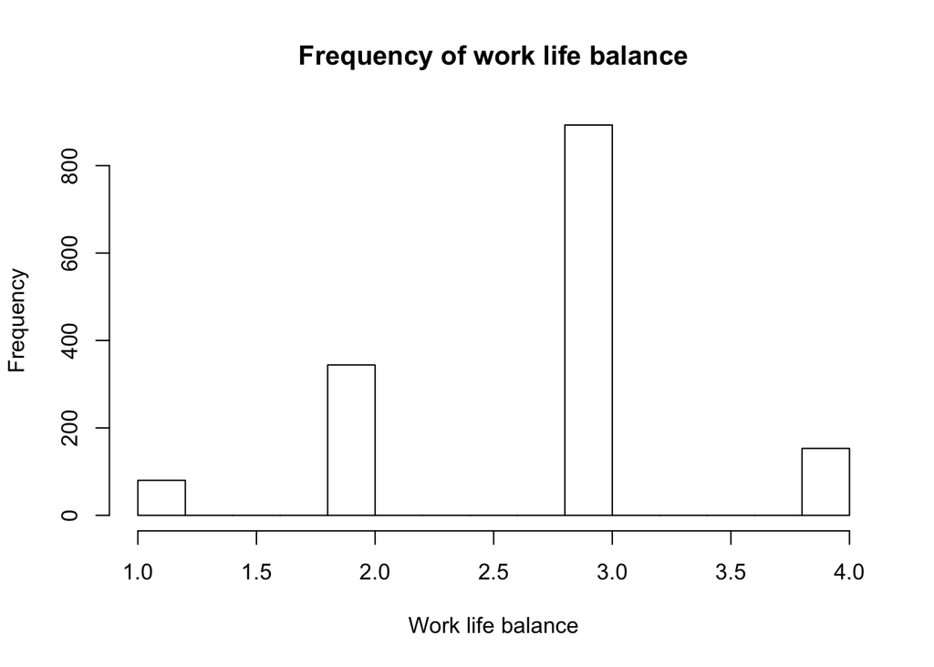

```r
hist(Data$WrkLifeBal, main='Frequency of work life balance', xlab='Work life balance')
```

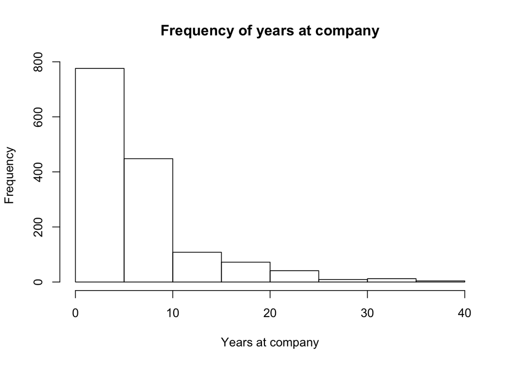

```r
hist(Data$YrsAtCompany, main='Frequency of years at company', xlab = 'Years at company')
```

3c) Give the frequencies (in table format or similar) for Gender, Education, and Occupation. They can be separate tables, if that’s your choice.

```r
table(Data$Gender, Data$Education, Data$JobRole)
```

```
## , ,  = Healthcare Representative
##
##
##           1  2  3  4  5
##   Female  7  7 18 19  0
##   Male    8 14 30 25  3
##
## , ,  = Human Resources
##
##
##           1  2  3  4  5
##   Female  1  3  8  4  0
##   Male    4  9 14  6  3
##
## , ,  = Laboratory Technician
##
##
##           1  2  3  4  5
##   Female 10 18 34 21  2
##   Male   25 39 70 37  3
##
## , ,  = Manager
##
##
##           1  2  3  4  5
##   Female  3  6 21 14  3
##   Male    6 13 19 15  2
##
## , ,  = Manufacturing Director
##
##
##           1  2  3  4  5
##   Female  5 18 27 18  4
##   Male   10 15 27 20  1
##
## , ,  = Research Director
##
##
##           1  2  3  4  5
##   Female  2  6 12  8  5
##   Male    5  7 18 15  2
##
## , ,  = Research Scientist
##
##
##           1  2  3  4  5
##   Female 14 19 49 29  3
##   Male   23 27 73 50  5
##
## , ,  = Sales Executive
##
##
##           1  2  3  4  5
##   Female 12 33 49 33  5
##   Male   15 33 71 68  7
##
## , ,  = Sales Representative
##
##
##           1  2  3  4  5
##   Female  6  7 17  8  0
##   Male   14  8 15  8  0
```

3d) Give the counts (again, table) of management positions.

```r
table(Data$JobLevel)
```

```
##
##   1   2   3   4   5
## 543 534 218 106  69
```

4. Deeper Analysis and Visualization

4a) You should make all of these appealing looking. Remember to include things like a clean, informative title, axis labels that are in plain English, and readable axis values that do not overlap.

4b) Create bar charts in ggplot or similar. The bars should be in descending order, Use any color palette of your choice other than the default.

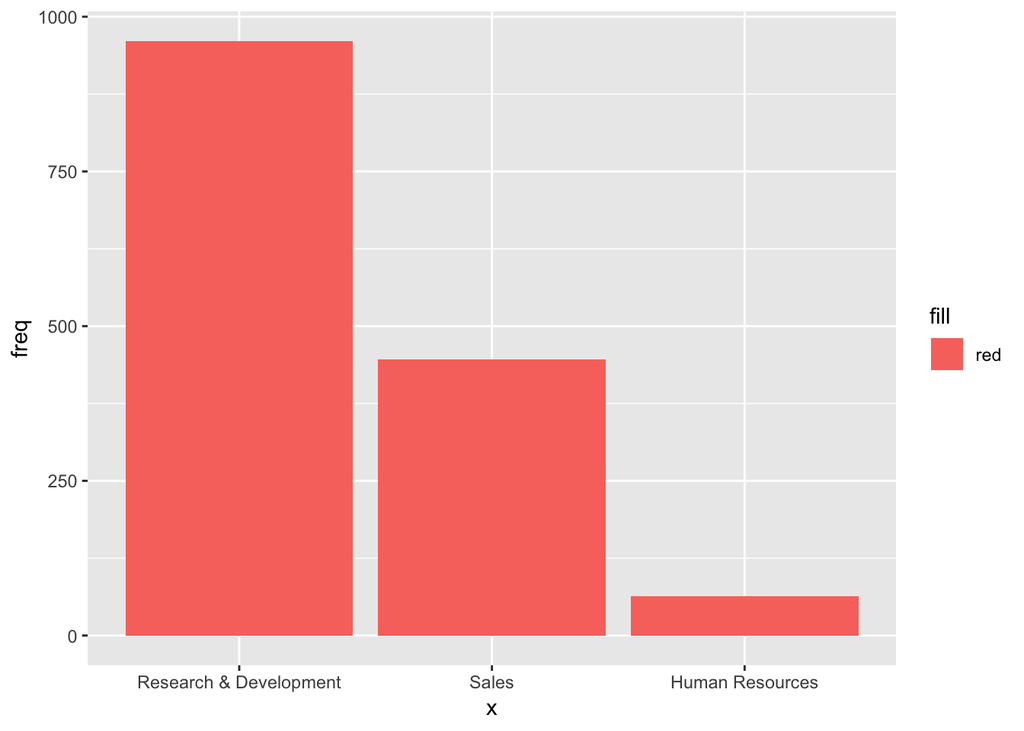

```r
library(plyr)
library(ggplot2)
Dep = count(Data$Department)
Dep<- Dep[order(Dep$freq),]
Dep$x <- factor(Dep$x, levels = Dep$x[order(-Dep$freq)])
ggplot(data=Dep, aes(x=x, y=freq, fill='red'))+geom_bar(stat='identity')
```

4c) Is there a relationship between Age and Income? Create a scatterplot and make an assessment of whether there is a relationship. Color each point based on the Gender of the participant. You’re welcome to use lm() or similar functions to back up your claims

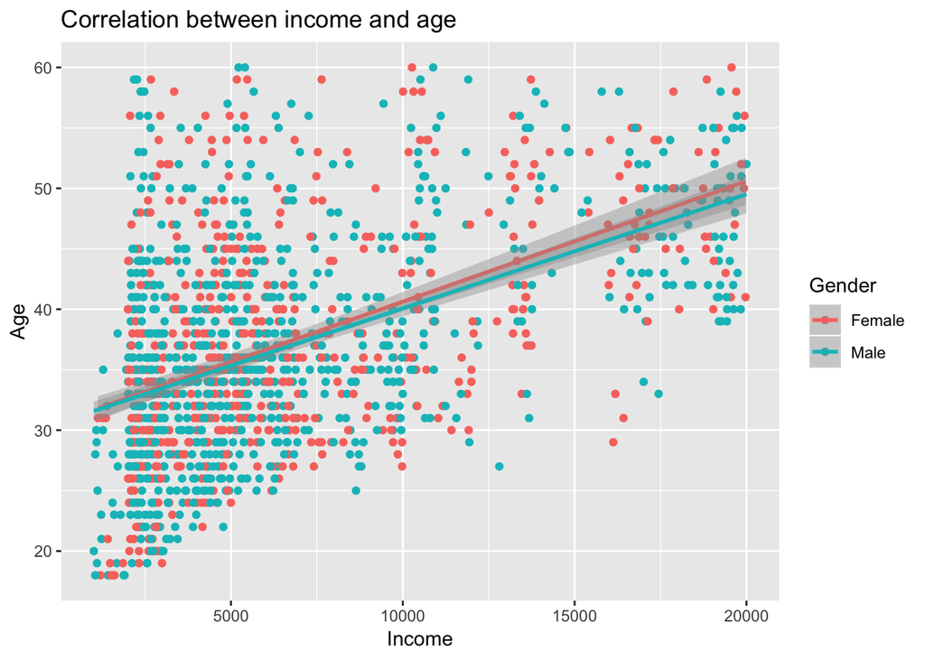

```r
library(ggplot2)
Age <- Data$Age
Income <- Data$MonthlyIncm
Gender <- Data$Gender
ggplot(Data, aes (Income, Age, color = Gender)) + geom_point()+ggtitle("Correlation between income and age")+geom_smooth(method = lm)
```

```r
cor.test(Age,Income)
```

```
##
##  Pearson's product-moment correlation
##
## data:  Age and Income
## t = 21.995, df = 1468, p-value < 2.2e-16
## alternative hypothesis: true correlation is not equal to 0
## 95 percent confidence interval:
##  0.4583951 0.5353551
## sample estimates:
##       cor
## 0.4978546
```

4d) What about Life Satisfaction? Create another scatterplot. Is there a discernible relationship there to what?

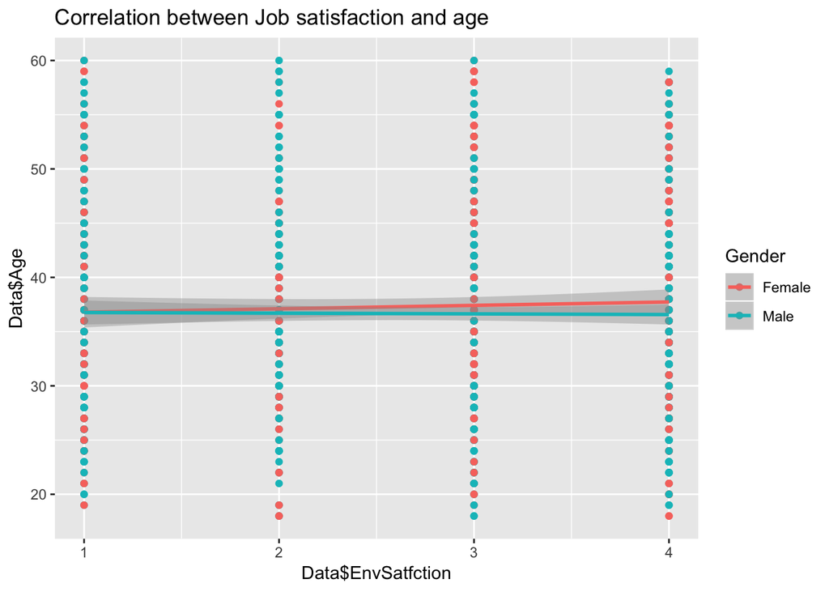

```r
ggplot(Data, aes (Data$EnvSatfction, Data$Age, color = Gender)) + geom_point()+ggtitle("Correlation between Job satisfaction and age")+geom_smooth(method = lm)
```

```r
cor.test(Data$EnvSatfction,Data$Age)
```

```
##
##  Pearson's product-moment correlation
##
## data:  Data$EnvSatfction and Data$Age
## t = 0.38878, df = 1468, p-value = 0.6975
## alternative hypothesis: true correlation is not equal to 0
## 95 percent confidence interval:
##  -0.04100230  0.06124211
## sample estimates:
##        cor
## 0.01014643
```

```r
cor.test(Data$EnvSatfction,Data$DailyRate)
```

```
##
##  Pearson's product-moment correlation
##
## data:  Data$EnvSatfction and Data$DailyRate
## t = 0.70338, df = 1468, p-value = 0.4819
## alternative hypothesis: true correlation is not equal to 0
## 95 percent confidence interval:
##  -0.03280339  0.06941717
## sample estimates:
##        cor
## 0.01835485
```

```r
cor.test(Data$EnvSatfction,Data$DistFromHome)
```

```
##
##  Pearson's product-moment correlation
##
## data:  Data$EnvSatfction and Data$DistFromHome
## t = -0.616, df = 1468, p-value = 0.538
## alternative hypothesis: true correlation is not equal to 0
## 95 percent confidence interval:
##  -0.06714760  0.03508096
## sample estimates:
##         cor
## -0.01607533
```

```r
cor.test(Data$EnvSatfction,Data$Education)
```

```
##
##  Pearson's product-moment correlation
##
## data:  Data$EnvSatfction and Data$Education
## t = -1.0398, df = 1468, p-value = 0.2986
## alternative hypothesis: true correlation is not equal to 0
## 95 percent confidence interval:
##  -0.07814738  0.02403248
## sample estimates:
##         cor
## -0.02712831
```

```r
cor.test(Data$EnvSatfction,Data$EmployeeCnt)
```

```
##
##  Pearson's product-moment correlation
##
## data:  Data$EnvSatfction and Data$EmployeeCnt
## t = NA, df = 1468, p-value = NA
## alternative hypothesis: true correlation is not equal to 0
## 95 percent confidence interval:
##  NA NA
## sample estimates:
## cor
##  NA
```

```r
cor.test(Data$EnvSatfction,Data$EmployeeNum)
```

```
##
##  Pearson's product-moment correlation
##
## data:  Data$EnvSatfction and Data$EmployeeNum
## t = 0.67524, df = 1468, p-value = 0.4996
## alternative hypothesis: true correlation is not equal to 0
## 95 percent confidence interval:
##  -0.03353687  0.06868638
## sample estimates:
##       cor
## 0.0176208
```

```r
cor.test(Data$EnvSatfction,Data$JobSatfction)
```

```
##
##  Pearson's product-moment correlation
##
## data:  Data$EnvSatfction and Data$JobSatfction
## t = -0.25994, df = 1468, p-value = 0.7949
## alternative hypothesis: true correlation is not equal to 0
## 95 percent confidence interval:
##  -0.05789173  0.04435849
## sample estimates:
##          cor
## -0.006784353
```

```r
cor.test(Data$EnvSatfction,Data$HourlyRate)
```

```
##
##  Pearson's product-moment correlation
##
## data:  Data$EnvSatfction and Data$HourlyRate
## t = -1.9126, df = 1468, p-value = 0.05599
## alternative hypothesis: true correlation is not equal to 0
## 95 percent confidence interval:
##  -0.100727652  0.001273747
## sample estimates:
##         cor
## -0.04985696
```

```r
cor.test(Data$EnvSatfction,Data$JobInvolmnt)
```

```
##
##  Pearson's product-moment correlation
##
## data:  Data$EnvSatfction and Data$JobInvolmnt
## t = -0.31716, df = 1468, p-value = 0.7512
## alternative hypothesis: true correlation is not equal to 0
## 95 percent confidence interval:
##  -0.05937992  0.04286800
## sample estimates:
##          cor
## -0.008277598
```

```r
cor.test(Data$EnvSatfction,Data$JobLevel)
```

```
##
##  Pearson's product-moment correlation
##
## data:  Data$EnvSatfction and Data$JobLevel
## t = 0.046426, df = 1468, p-value = 0.963
## alternative hypothesis: true correlation is not equal to 0
## 95 percent confidence interval:
##  -0.04991885  0.05233591
## sample estimates:
##         cor
## 0.001211699
```

```r
cor.test(Data$EnvSatfction,Data$MonthlyIncm)
```

```
##
##  Pearson's product-moment correlation
##
## data:  Data$EnvSatfction and Data$MonthlyIncm
## t = -0.23982, df = 1468, p-value = 0.8105
## alternative hypothesis: true correlation is not equal to 0
## 95 percent confidence interval:
##  -0.05736819  0.04488273
## sample estimates:
##          cor
## -0.006259088
```

```r
cor.test(Data$EnvSatfction,Data$MonthlyRate)
```

```
##
##  Pearson's product-moment correlation
##
## data:  Data$EnvSatfction and Data$MonthlyRate
## t = 1.4416, df = 1468, p-value = 0.1496
## alternative hypothesis: true correlation is not equal to 0
## 95 percent confidence interval:
##  -0.01355389  0.08855684
## sample estimates:
##        cor
## 0.03759962
```

```r
cor.test(Data$EnvSatfction,Data$NumCmpWorked)
```

```
##
##  Pearson's product-moment correlation
##
## data:  Data$EnvSatfction and Data$NumCmpWorked
## t = 0.48258, df = 1468, p-value = 0.6295
## alternative hypothesis: true correlation is not equal to 0
## 95 percent confidence interval:
##  -0.03855796  0.06368077
## sample estimates:
##        cor
## 0.01259432
```

```r
cor.test(Data$EnvSatfction,Data$PrcntSalHike)
```

```
##
##  Pearson's product-moment correlation
##
## data:  Data$EnvSatfction and Data$PrcntSalHike
## t = -1.2152, df = 1468, p-value = 0.2245
## alternative hypothesis: true correlation is not equal to 0
## 95 percent confidence interval:
##  -0.08269462  0.01945780
## sample estimates:
##        cor
## -0.0317012
```

```r
cor.test(Data$EnvSatfction,Data$PerfRating)
```

```
##
##  Pearson's product-moment correlation
##
## data:  Data$EnvSatfction and Data$PerfRating
## t = -1.1326, df = 1468, p-value = 0.2576
## alternative hypothesis: true correlation is not equal to 0
## 95 percent confidence interval:
##  -0.08055372  0.02161215
## sample estimates:
##         cor
## -0.02954795
```

```r
cor.test(Data$EnvSatfction,Data$RlnSatfctn)
```

```
##
##  Pearson's product-moment correlation
##
## data:  Data$EnvSatfction and Data$RlnSatfctn
## t = 0.2937, df = 1468, p-value = 0.769
## alternative hypothesis: true correlation is not equal to 0
## 95 percent confidence interval:
##  -0.04347911  0.05876981
## sample estimates:
##         cor
## 0.007665384
```

```r
cor.test(Data$EnvSatfction,Data$StandardHrs)
```

```
##
##  Pearson's product-moment correlation
##
## data:  Data$EnvSatfction and Data$StandardHrs
## t = NA, df = 1468, p-value = NA
## alternative hypothesis: true correlation is not equal to 0
## 95 percent confidence interval:
##  NA NA
## sample estimates:
## cor
##  NA
```

```r
cor.test(Data$EnvSatfction,Data$StockOptLvl)
```

```
##
##  Pearson's product-moment correlation
##
## data:  Data$EnvSatfction and Data$StockOptLvl
## t = 0.1315, df = 1468, p-value = 0.8954
## alternative hypothesis: true correlation is not equal to 0
## 95 percent confidence interval:
##  -0.04770367  0.05455004
## sample estimates:
##         cor
## 0.003432158
```

```r
cor.test(Data$EnvSatfction,Data$TotWrkngYrs)
```

```
##
##  Pearson's product-moment correlation
##
## data:  Data$EnvSatfction and Data$TotWrkngYrs
## t = -0.10318, df = 1468, p-value = 0.9178
## alternative hypothesis: true correlation is not equal to 0
## 95 percent confidence interval:
##  -0.05381312  0.04844106
## sample estimates:
##         cor
## -0.00269307
```

```r
cor.test(Data$EnvSatfction,Data$WrkLifeBal)
```

```
##
##  Pearson's product-moment correlation
##
## data:  Data$EnvSatfction and Data$WrkLifeBal
## t = 1.0589, df = 1468, p-value = 0.2898
## alternative hypothesis: true correlation is not equal to 0
## 95 percent confidence interval:
##  -0.02353340  0.07864367
## sample estimates:
##       cor
## 0.0276273
```

```r
cor.test(Data$EnvSatfction,Data$YrsAtCompany)
```

```
##
##  Pearson's product-moment correlation
##
## data:  Data$EnvSatfction and Data$YrsAtCompany
## t = 0.055845, df = 1468, p-value = 0.9555
## alternative hypothesis: true correlation is not equal to 0
## 95 percent confidence interval:
##  -0.04967361  0.05258109
## sample estimates:
##         cor
## 0.001457549
```

```r
cor.test(Data$EnvSatfction,Data$YrsInCrntRl)
```

```
##
##  Pearson's product-moment correlation
##
## data:  Data$EnvSatfction and Data$YrsInCrntRl
## t = 0.69006, df = 1468, p-value = 0.4903
## alternative hypothesis: true correlation is not equal to 0
## 95 percent confidence interval:
##  -0.03315052  0.06907132
## sample estimates:
##        cor
## 0.01800746
```

```r
cor.test(Data$EnvSatfction,Data$YrsSncLstPrm)
```

```
##
##  Pearson's product-moment correlation
##
## data:  Data$EnvSatfction and Data$YrsSncLstPrm
## t = 0.62053, df = 1468, p-value = 0.535
## alternative hypothesis: true correlation is not equal to 0
## 95 percent confidence interval:
##  -0.03496280  0.06726537
## sample estimates:
##        cor
## 0.01619361
```

```r
cor.test(Data$EnvSatfction,Data$EnvSatfction)
```

```
##
##  Pearson's product-moment correlation
##
## data:  Data$EnvSatfction and Data$EnvSatfction
## t = Inf, df = 1468, p-value < 2.2e-16
## alternative hypothesis: true correlation is not equal to 0
## 95 percent confidence interval:
##  1 1
## sample estimates:
## cor
##   1
```